# Bayesian plant survival analysis

Kevin Schoelz

May 2019

In this notebook, we are looking how genotype of a given plant species will affect the plant resistance to disease. To do this we have data from the following experiment.

Plants are of different genotypes are prepared. The plants are then all inoculated with the virus at the same time. Plants are observed once each day to see if symptoms have developed. The result is that we have a dataset with each plant labeled with an id, genotype, and when the plant developed local symptoms, and when it became generally symptomatic. There are several types of genotypes, and the experiment is repeated at different times of the year over a five year period.

To begin the analysis, we load some useful libraries.

```r
library(tidyverse)
library(tidybayes)
library(tufte)
library(rstan)
library(cowplot)
library(fastDummies)
library(survival)
library(survminer)

rstan_options(auto_write = TRUE)
options(mc.cores = parallel::detectCores())

#ggplot2 settings
theme_set(theme_cowplot())
```

# Importing and visualizing data

We can start by importing the data. From previous notebook, the data has already been organized into a tidy format. One thing we want to do is expand the Ecotype column into a series of indicator columns. This will eventually serve as the basis for the covariate matrix.

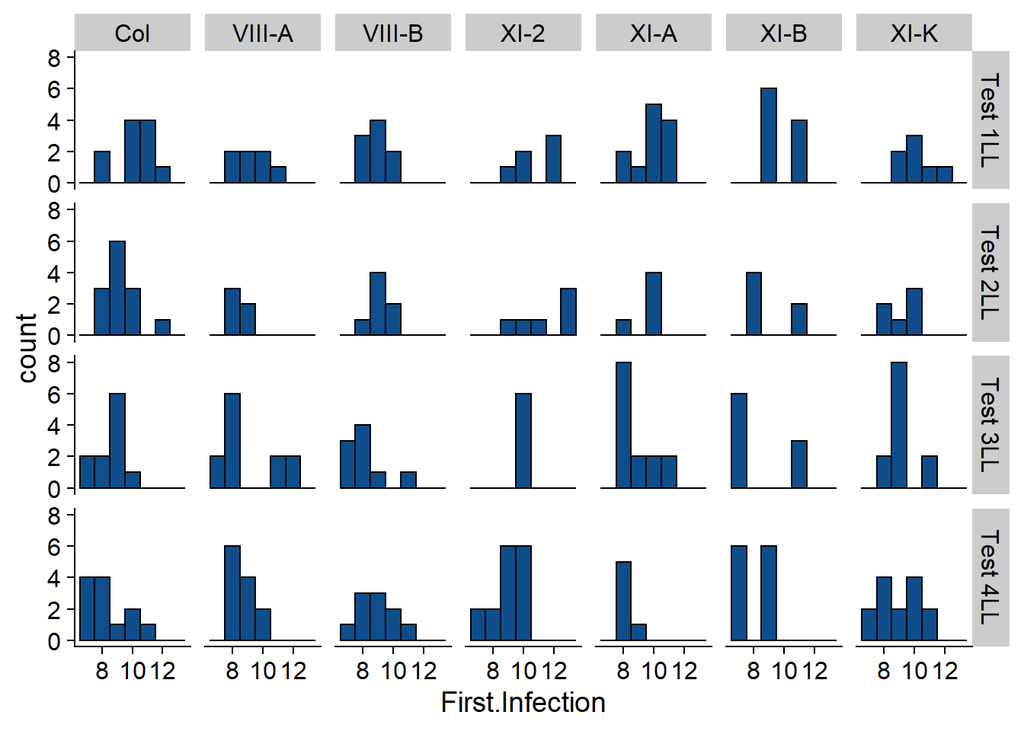

```r
df <- read.csv("unpacked_plant_data.csv")
# Take the Ecotype Variable and separate it out into covariate columns
df <- dummy_columns(df, select_columns = c("Ecotype", "Trial.Name"))

real_hist <- ggplot(data = df %>% filter(Censored == 0), aes(First.Infection)) +
  geom_histogram(binwidth = 1, color = "Black", fill = "DodgerBlue4") +
  facet_grid(Trial.Name ~ Ecotype)

real_hist
```

## Kaplan Meier estimators

We want to estimate the survival function for the various ecotypes. To start with, we are going to try to estimate the survival function using the Kaplan Meier estimator. We can do this using the `survival` package.

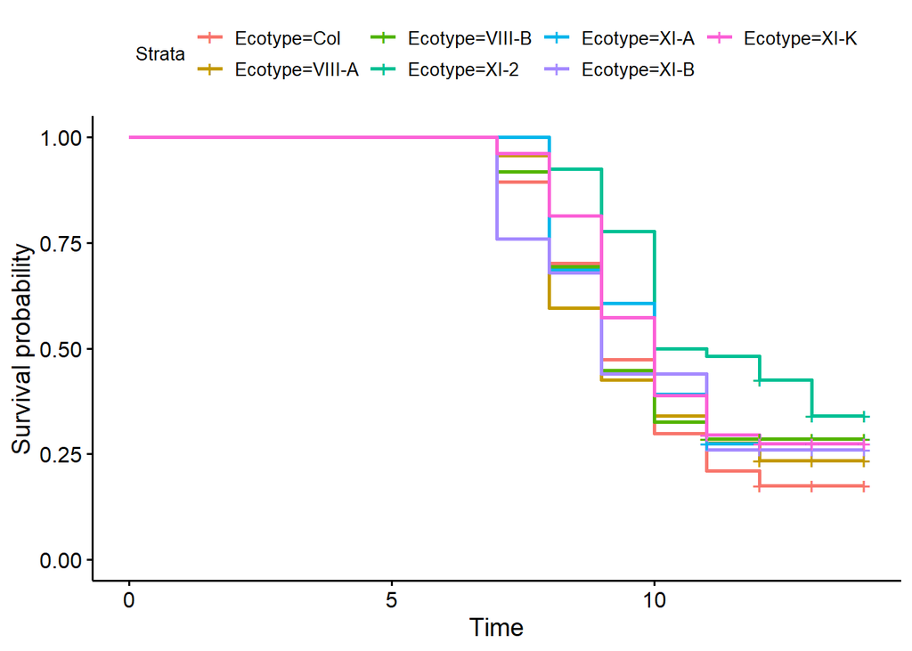

```r
surv_object <- Surv(time = df$First.Infection, event = ifelse(df$Censored==0, 1, 0))

fit1 <- survfit(surv_object ~ df$Ecotype, data = df)

#str(fit1)
#summary(fit1)

ggsurvplot(fit1, data = df)
```

# Weibull survival model with complete pooling

We are going to fit a series of models to this data. In this notebook, we will be focusing on Cox proportional hazard models with Weibull hazard function, given below

$$h(y) = \frac{\alpha}{\sigma^{\alpha}}y^{\alpha-1}$$
where $y$ is the time, $\alpha$ is the shape parameter of the Weibull distribution, and $\sigma$ is the scale parameter of the Weibull distribution.

We can relate the scale parameter to the covariates by setting

$$\sigma = \exp \left( \beta_{0} + X\beta \right)$$
where $X$ is the $N \times M$ covariate matrix with $M$ covariates and $N$ data points, $\beta_{0}$ is the intercept parameter containing information about the environment not contained in the covariates and $\beta$ is a vector with $M$ elements representing the effects of the different variables.

We can now write down our first probabilisitic model.

$$\begin{alignat*}{6}
&\beta_{0} &\sim &~N(0,10) \\
&\beta & \sim & ~N(0,1) \\
&\sigma & = & ~\exp \left( \beta_{0} + X\beta \right) \\
&y_{obs} & \sim & \frac{\alpha}{\sigma}\left( \frac{y}{\sigma}\right)^{\alpha - 1}\exp \left( -\left( \frac{y}{\sigma} \right)^{\alpha} \right)
\end{alignat*}$$

## Identify data and parameters

We can use Stan to calculate the prior predictive distribution. For now, we will remove all censored data. We have reason to believe that most of the censored data consists of plants that will not show symptoms, so we will simply remove these from the data set for now. Later, we can analyze with a cure model in order to include this data.

```r
# Look at only uncensored data
uncensored_df <- df %>% filter(Censored==0)

# Extract First.Infection times
y <- uncensored_df$First.Infection

# Extract Covariate matrix
Ecotype_Cols <- data.frame( X = colnames(uncensored_df)) %>% filter(startsWith(as.character(X), "Ecotype_"))
X <- uncensored_df %>% select(6:11)
X <- as.matrix(X)

# Get dimension sizes
n_covariates = dim(X)[2]
n_samples = dim(X)[1]
```

## Prior predictive check

Before we fit the data, we want to get simulated data from our prior predictive distribution. This will allow us to check the validity of the model.

```r
# Identify the data

sjp_data = list(n_covariates = n_covariates,
                n_samples = n_samples,
                X = X)

R = 10

sjp_fit <- stan(file = "sjp_weibull_completepooling.stan",
            data = sjp_data,
            iter = R,
            chains = 1,
            algorithm = "Fixed_param")
```

## Model fitting

```r
data = list(y = y,
            X = X,
            n_covariates = dim(X)[2],
            n_samples = dim(X)[1])

fit <- stan(file = "fit_weibull_completepooling.stan",
            data = data,
            iter = 1000,
            chains = 4)
```

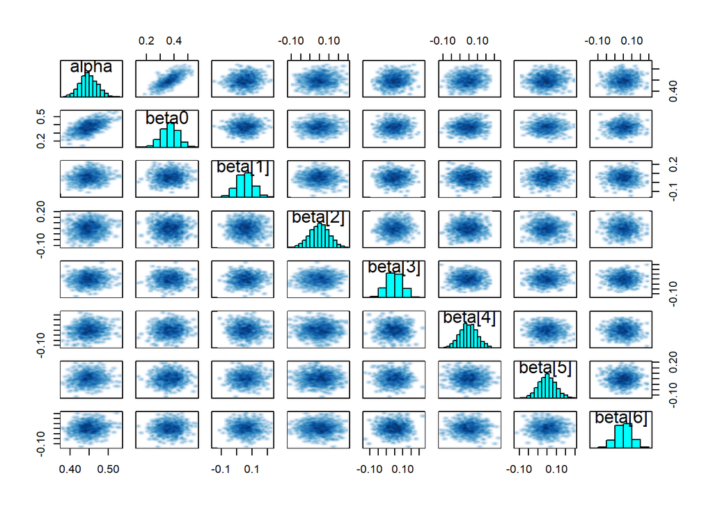

```r
pars = c("alpha", "beta0", "beta[1]", "beta[2]", "beta[3]", "beta[4]", "beta[5]", "beta[6]")

summary_fit <- as.data.frame(summary(fit, pars = pars))

summary_fit$row.number <- seq(1:nrow(summary_fit))

pairs(fit, pars = pars)
```

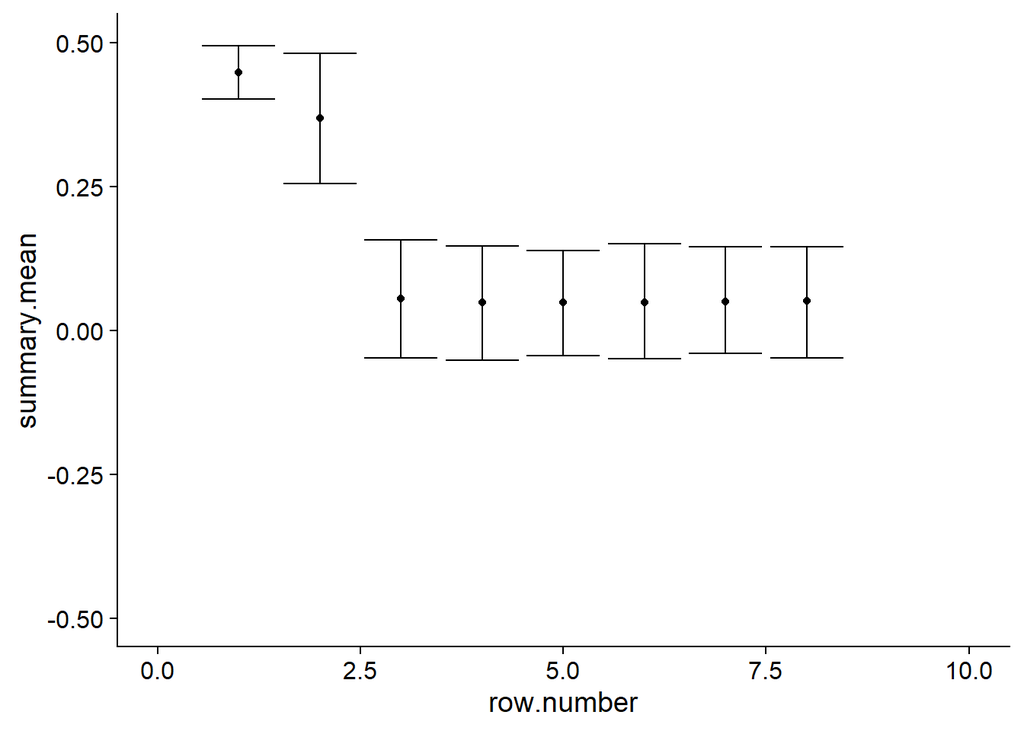

```r
ggplot(data = summary_fit, aes(x = row.number, y=summary.mean, ymin = summary.2.5., ymax=summary.97.5.)) +
  geom_errorbar() +
  geom_point() +
  ylim(-0.5,0.5) +
  xlim(0,10)
```